# maps-bovid-ecometrics

Andrew Barr

September 15, 2015

## Preliminaries

```r
library(rgdal)
library(rgeos)
library(maptools)
library(dplyr)
library(raster)
library(tidyr)
library(reshape2)
library(GISTools)

par.original <- par(no.readonly=TRUE)

summarize_regression <- function(model, round=2, label=""){
  mod_summary <- summary(model)
  return(knitr::kable(data.frame(
    label=label,
    intercept=round(mod_summary$coefficients[1,1],round),
    SEI=round(mod_summary$coefficients[1,2],round),
    slope=round(mod_summary$coefficients[2,1],round),
    SES=round(mod_summary$coefficients[2,2],round),
    r2 = round(mod_summary$adj.r.squared,round)
    )))
}

summarize_ANOVA <- function(model, round=2, label=""){
  mod_summary <- summary(model)
  return(knitr::kable(data.frame(
    label=label,
    ## a litte tricky to get correct coeffs
    # because the coefficients are in the original order, even though I used a ordered factor in the lm()
    forest=round(mod_summary$coefficients[1,1],round),
    wetland=round(mod_summary$coefficients[6,1],round),
    woodySav=round(mod_summary$coefficients[3,1],round),
    sav=round(mod_summary$coefficients[4,1],round),
    openShrub=round(mod_summary$coefficients[2,1],round),
    grass=round(mod_summary$coefficients[5,1],round),
    barren=round(mod_summary$coefficients[7,1],round),
    r2 = round(mod_summary$adj.r.squared,round)
    )))
}
```

## Load africa

```r
#get base file path to load data files...assumes file paths are from perspective of directory containing this file
base_path <- getwd()
africa <- readOGR(paste0(base_path,"/africa_shp/africa.shp"), "africa")
```

## Load bovids and merge based on taxonomic name

```r
bovids <- readOGR(paste0(base_path,"/IUCN-Redlist/AFRICAN_BOVIDS.shp"), "AFRICAN_BOVIDS")
bovids <- spTransform(bovids, proj4string(africa))

mergedBovidPolys <- unionSpatialPolygons(bovids, IDs = bovids@data$id_no)
mergedBovidAttributes <- group_by(bovids@data, id_no) %>% summarize(binomial = unique(binomial))
class(mergedBovidAttributes) <- "data.frame"
rownames(mergedBovidAttributes) <- mergedBovidAttributes$id_no
bovids <- SpatialPolygonsDataFrame(mergedBovidPolys, mergedBovidAttributes)
rm(mergedBovidAttributes,mergedBovidPolys)

#eliminate outlier taxa, because they are is usually the only taxon in the community and are north of Sahara
##
outliers <- c(which(bovids@data$binomial == "Ammotragus lervia"), which(bovids@data$binomial == "Gazella cuvieri"), which(bovids@data$binomial == "Addax nasomaculatus"))
bovids <- bovids[-outliers,]
```

## Make raster

```r
africaRaster <- raster(extent(africa), res=c(50000,50000), crs=CRS(proj4string(africa)))
africaRaster <- mask(africaRaster, africa)
```

## Compute bovid species richness

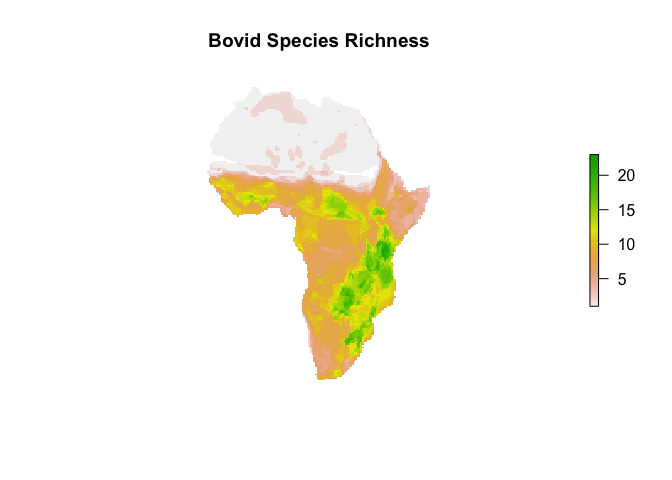

```r
bovidRichness <- rasterize(x=bovids, y=africaRaster, fun='count', field="id_no")
plot(bovidRichness, axes=F, box=F, main="Bovid Species Richness")
```

```r
joinedDFs <- read.table("all_ecomorphic_data.csv", sep=",", header=T)
bovids@data$B <- joinedDFs$B/joinedDFs$geomeans
bovids@data$DistRad <- joinedDFs$DistRad/joinedDFs$geomeans
bovids@data$ProxRad <- joinedDFs$ProxRad/joinedDFs$geomeans
bovids@data$MML <- joinedDFs$MML/joinedDFs$geomeans
bovids@data$WAF <- joinedDFs$WAF/joinedDFs$geomeans

bovids@data$relMidshaftWidth <- joinedDFs$relMidshaftWidth
bovids@data$relMetarsalLength <- joinedDFs$relMetarsalLength
bovids@data$relMetatarsalDepth <- joinedDFs$relMetatarsalDepth
bovids@data$medialVert <- joinedDFs$medialVert
bovids@data$distalArticular <- joinedDFs$distalArticular
```

## Load MAP raster

```r
MAP <- raster(paste0(base_path,"/globalMAP_2point5_arcseconds.grd"))
MAP <- projectRaster(MAP, africaRaster)
```

## Load land cover raster

```r
landCover <- raster(paste0(base_path,"/AFRICA_LandCover.TIFF"))
landCover <- projectRaster(landCover, africaRaster, method="ngb")
values(landCover)[values(landCover) %in% c(0, 1, 3, 4, 5, 6, 12, 13, 14)] <- NA
#method = 'ngb' refers to nearest neighbor, useful for categorical rasters
```

## function to do a single variable

```r
doEcometricAnalysis <- function(var,
                                originalMAP,
                                originalLandCover,
                                savePlots=FALSE,
                                dir=base_path,
                                width=5, height=5,
                                cex.main=1.75,
                                plotLabel=NULL,
                                scaleBar=FALSE,
                                northArrow=FALSE,
                                returnLMs=TRUE,
                                writeEcometricRaster=FALSE) {
  stopifnot(var %in% names(bovids@data))
  ecometric <- rasterize(x=bovids,
                         y=africaRaster,
                         fun=function(x, ...) {mean(x, na.rm=TRUE)},
                         field=var)
  plot(ecometric,axes=F,box=F, main=paste("mean", var))
  if(writeEcometricRaster) writeRaster(ecometric, paste0(base_path,"/ecometricRasters/",var,".tif"), overwrite=TRUE)

  MAP <- mask(originalMAP, ecometric)

  MAPlm <- lm(scale(values(ecometric))~sqrt(values(MAP)))
  summary(MAPlm)
  plot(scale(values(ecometric))~sqrt(values(MAP)), pch=16, xlab="sqrt(MAP)", ylab=var)
  abline(reg=MAPlm, col="red", lty=2)

  landCover <- mask(originalLandCover, ecometric)
  landCoverFactor <- factor(values(landCover))
  levels(landCoverFactor) <- c("Evergreen\nBroad. Forest",
                               "Open\nShrub.",
                               "Woody\nSavannas",
                               "Savannas",
                               "Grasslands",
                               "Perm.\nWetland",
                               "Barren")
  landCoverFactor <- ordered(landCoverFactor,
                     levels=c("Evergreen\nBroad. Forest", "Perm.\nWetland","Woody\nSavannas", "Savannas","Open\nShrub.","Grasslands",  "Barren"))
  plot(scale(values(ecometric))~landCoverFactor, col=(terrain.colors(7)), las=2, xlab="", ylab="", main=var)
  box()


  if(savePlots){
    pdf(file = paste0(dir,"/",var,".pdf"), width=width, height=height)
    plot(scale(ecometric), axes=FALSE, box=F)
    text(1636265, 3249920, labels=ifelse(is.null(plotLabel), var, plotLabel), cex=cex.main)
    if(scaleBar){
      scalebar(c(-1795336,-911192.4), d=1000000, divs=2, label="1000 km", adj=c(0,-1),type="bar")
      north.arrow(-1198181, -1670000,len = 100000, lab = "N")
    }
    dev.off()

    pdf(file = paste0(dir,"/",var,"-MAPscatterplot.pdf"), width=width, height=height)
    plot(scale(values(ecometric))~sqrt(values(MAP)), pch=16, xlab="sqrt(MAP)", ylab=ifelse(is.null(plotLabel), var, plotLabel), main=ifelse(is.null(plotLabel), var, plotLabel), cex.main=cex.main)
    abline(reg=MAPlm, col="red", lty=5, lwd=3)
    dev.off()

    pdf(file = paste0(dir,"/",var,"-landcoverBoxplots.pdf"), width=width*1.8, height=height)
    plot(scale(values(ecometric))~landCoverFactor, col=(terrain.colors(7)), xlab="", ylab="", main=ifelse(is.null(plotLabel), var, plotLabel), cex.main=cex.main, cex.lab=0.5)
    dev.off()

    }

  print(summarize_regression(MAPlm, 2, label=sprintf("MAP~%s", var)))

  options(contrasts = c("contr.treatment", "contr.treatment")) #nesseary to have treament contrasts for ordered factors
  LClm <- lm(scale(values(ecometric))~landCoverFactor)
  print(summarize_ANOVA(LClm, 2, label=sprintf("LC~%s", var)))
  if(returnLMs) return(list(unscaledLC=lm(values(ecometric)~landCoverFactor),
                            unscaledMAP=lm(values(ecometric)~sqrt(values(MAP)))
                            )
                      )
  }
```

## B

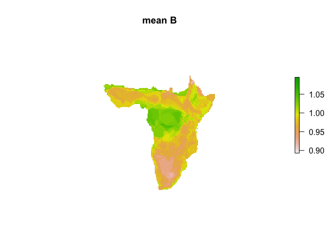

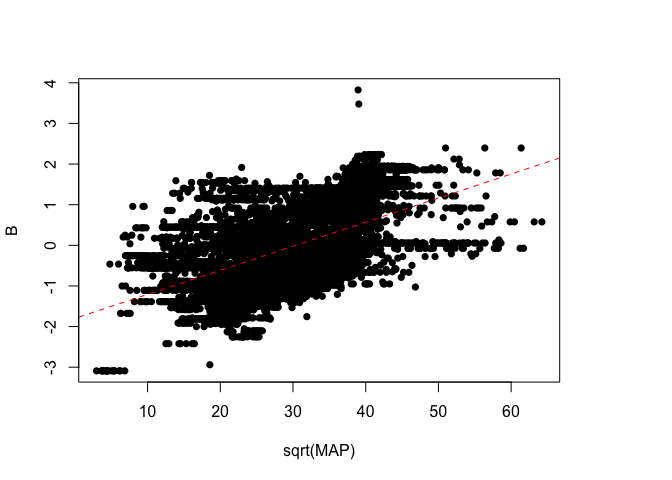

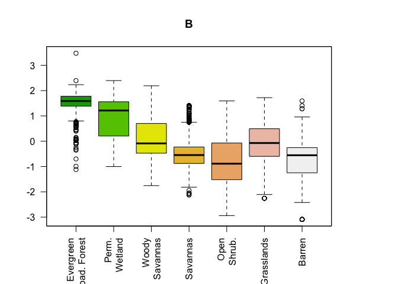

| label | intercept | SEI | slope | SES | r2 |
| --- | --- | --- | --- | --- | --- |
| MAP~B | -1.8 | 0.03 | 0.06 | 0 | 0.3 |

| label | forest | wetland | woodySav | sav | openShrub | grass | barren | r2 |
| --- | --- | --- | --- | --- | --- | --- | --- | --- |
| LC~B | 1.44 | -1.5 | -1.34 | -2 | -0.55 | -2.19 | -2.22 | 0.5 |

```r
resB <- doEcometricAnalysis("B", MAP, landCover, savePlots = F)
```

```r
resB
```

$unscaledLC

Call: lm(formula = values(ecometric) ~ landCoverFactor)

Coefficients: (Intercept) landCoverFactorPerm.1.02526 -0.01596  
landCoverFactorWoodylandCoverFactorSavannas  
-0.03904 -0.05841  
landCoverFactorOpen. landCoverFactorGrasslands  
-0.06395 -0.04387  
landCoverFactorBarren  
-0.06491

$unscaledMAP

Call: lm(formula = values(ecometric) ~ sqrt(values(MAP)))

Coefficients: (Intercept) sqrt(values(MAP))  
0.93070 0.00173

## DistRad

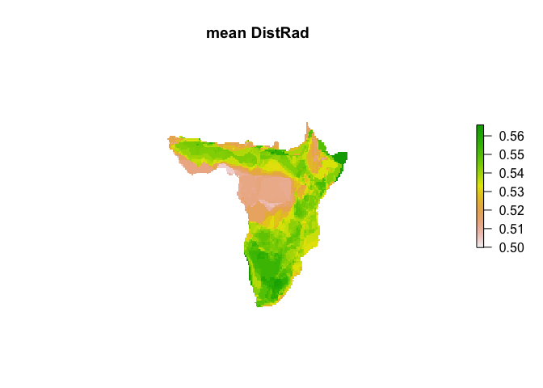

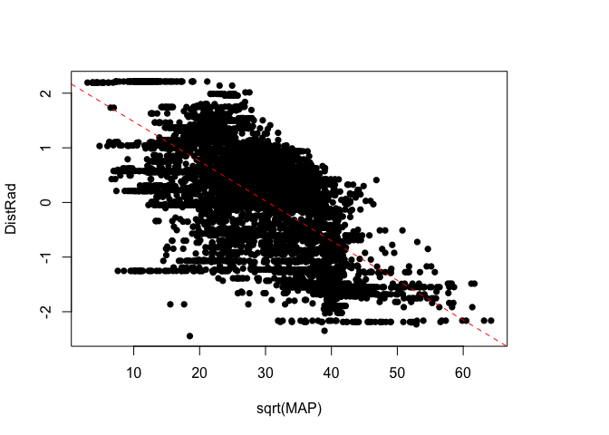

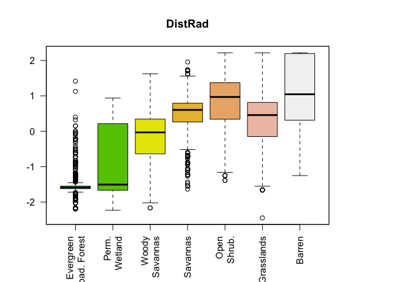

| label | intercept | SEI | slope | SES | r2 |
| --- | --- | --- | --- | --- | --- |
| MAP~DistRad | 2.21 | 0.03 | -0.07 | 0 | 0.45 |

| label | forest | wetland | woodySav | sav | openShrub | grass | barren | r2 |
| --- | --- | --- | --- | --- | --- | --- | --- | --- |
| LC~DistRad | -1.54 | 1.86 | 1.36 | 2.07 | 0.52 | 2.36 | 2.49 | 0.6 |

```r
resDistRad <- doEcometricAnalysis("DistRad", MAP, landCover, savePlots = F)
```

```r
resDistRad
```

$unscaledLC

Call: lm(formula = values(ecometric) ~ landCoverFactor)

Coefficients: (Intercept) landCoverFactorPerm.0.512682 0.007384  
landCoverFactorWoodylandCoverFactorSavannas  
0.019340 0.029324  
landCoverFactorOpen. landCoverFactorGrasslands  
0.033389 0.026428  
landCoverFactorBarren  
0.035357

$unscaledMAP

Call: lm(formula = values(ecometric) ~ sqrt(values(MAP)))

Coefficients: (Intercept) sqrt(values(MAP))  
0.565759 -0.001029

## ProxRad

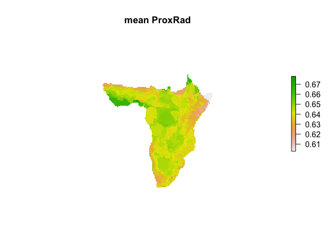

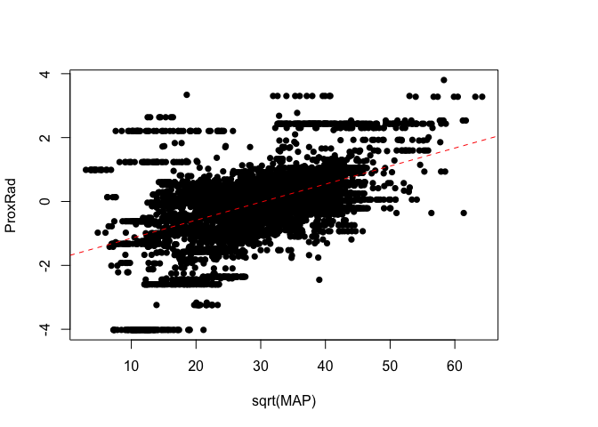

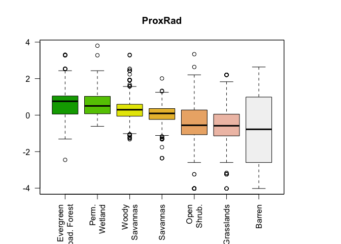

| label | intercept | SEI | slope | SES | r2 |
| --- | --- | --- | --- | --- | --- |
| MAP~ProxRad | -1.71 | 0.03 | 0.06 | 0 | 0.27 |

| label | forest | wetland | woodySav | sav | openShrub | grass | barren | r2 |
| --- | --- | --- | --- | --- | --- | --- | --- | --- |
| LC~ProxRad | 0.71 | -1.38 | -0.42 | -0.67 | -0.05 | -1.34 | -1.65 | 0.25 |

```r
resProxRad <- doEcometricAnalysis("ProxRad", MAP, landCover, savePlots = F)
```

```r
resProxRad
```

$unscaledLC

Call: lm(formula = values(ecometric) ~ landCoverFactor)

Coefficients: (Intercept) landCoverFactorPerm.0.6483258 -0.0004945  
landCoverFactorWoodylandCoverFactorSavannas  
-0.0040462 -0.0064014  
landCoverFactorOpen. landCoverFactorGrasslands  
-0.0128776 -0.0132598  
landCoverFactorBarren  
-0.0158172

$unscaledMAP

Call: lm(formula = values(ecometric) ~ sqrt(values(MAP)))

Coefficients: (Intercept) sqrt(values(MAP))  
0.6250522 0.0005415

## WAF

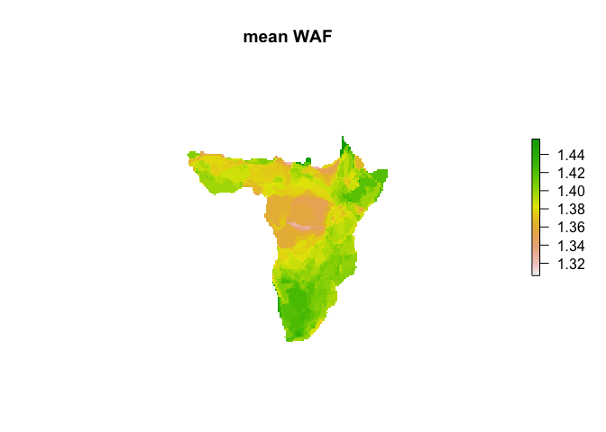

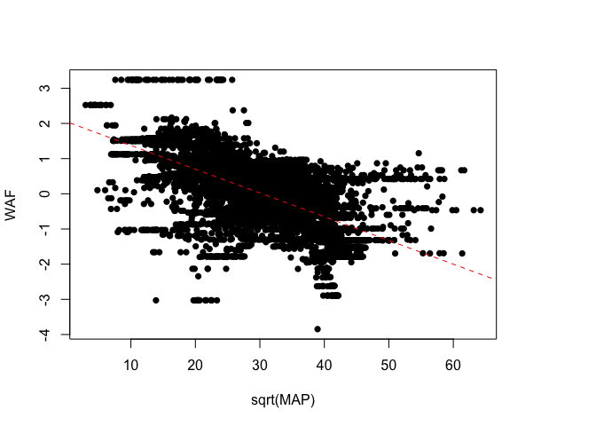

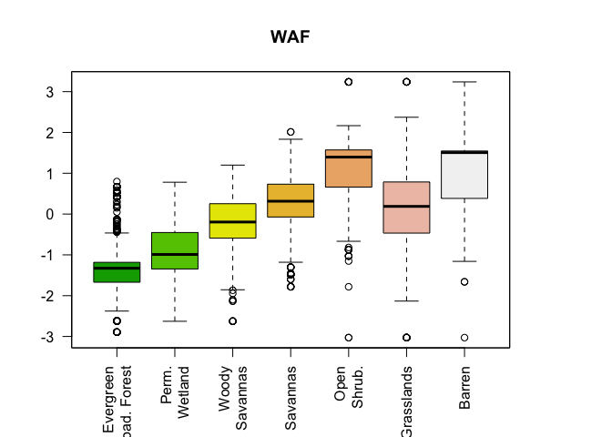

| label | intercept | SEI | slope | SES | r2 |
| --- | --- | --- | --- | --- | --- |
| MAP~WAF | 2.05 | 0.03 | -0.07 | 0 | 0.39 |

| label | forest | wetland | woodySav | sav | openShrub | grass | barren | r2 |
| --- | --- | --- | --- | --- | --- | --- | --- | --- |
| LC~WAF | -1.26 | 1.44 | 1.04 | 1.57 | 0.37 | 2.37 | 2.32 | 0.49 |

```r
resWAF <- doEcometricAnalysis("WAF", MAP, landCover, savePlots = F)
```

```r
resWAF
```

$unscaledLC

Call: lm(formula = values(ecometric) ~ landCoverFactor)

Coefficients: (Intercept) landCoverFactorPerm.1.36125 0.00791  
landCoverFactorWoodylandCoverFactorSavannas  
0.02211 0.03336  
landCoverFactorOpen. landCoverFactorGrasslands  
0.05023 0.03058  
landCoverFactorBarren  
0.04929

$unscaledMAP

Call: lm(formula = values(ecometric) ~ sqrt(values(MAP)))

Coefficients: (Intercept) sqrt(values(MAP))  
1.431597 -0.001433

## MML

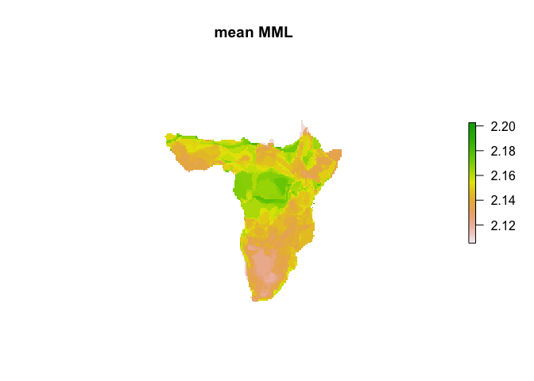

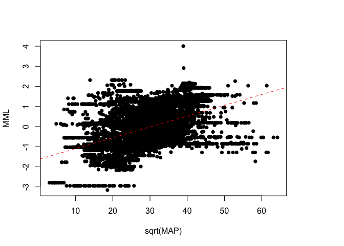

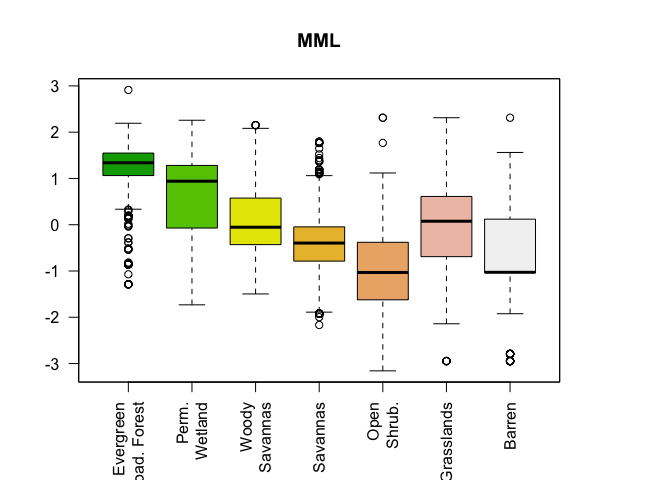

| label | intercept | SEI | slope | SES | r2 |
| --- | --- | --- | --- | --- | --- |
| MAP~MML | -1.63 | 0.04 | 0.05 | 0 | 0.24 |

| label | forest | wetland | woodySav | sav | openShrub | grass | barren | r2 |
| --- | --- | --- | --- | --- | --- | --- | --- | --- |
| LC~MML | 1.16 | -1.17 | -1.09 | -1.54 | -0.49 | -2.09 | -1.93 | 0.39 |

```r
resMML <- doEcometricAnalysis("MML", MAP, landCover, savePlots = F, scaleBar=TRUE, northArrow=TRUE, plotLabel="MMLa")
```

```r
resMML
```

$unscaledLC

Call: lm(formula = values(ecometric) ~ landCoverFactor)

Coefficients: (Intercept) landCoverFactorPerm.2.164034 -0.006629  
landCoverFactorWoodylandCoverFactorSavannas  
-0.014761 -0.020897  
landCoverFactorOpen. landCoverFactorGrasslands  
-0.028357 -0.015885  
landCoverFactorBarren  
-0.026193

$unscaledMAP

Call: lm(formula = values(ecometric) ~ sqrt(values(MAP)))

Coefficients: (Intercept) sqrt(values(MAP))  
2.1260486 0.0007309

## relMidshaftWidth

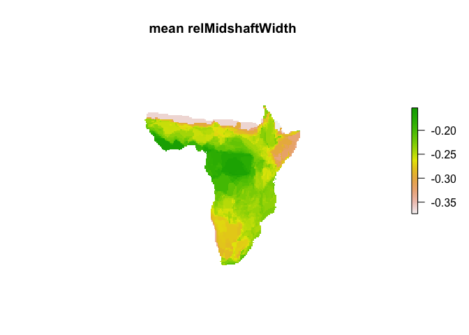

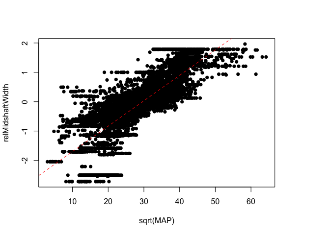

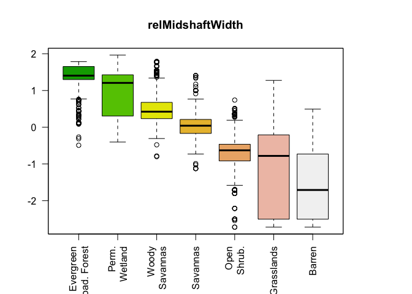

| label | intercept | SEI | slope | SES | r2 |
| --- | --- | --- | --- | --- | --- |
| MAP~relMidshaftWidth | -2.56 | 0.02 | 0.09 | 0 | 0.67 |

| label | forest | wetland | woodySav | sav | openShrub | grass | barren | r2 |
| --- | --- | --- | --- | --- | --- | --- | --- | --- |
| LC~relMidshaftWidth | 1.41 | -2.52 | -0.92 | -1.4 | -0.48 | -2.14 | -2.96 | 0.7 |

```r
resrelMidshaftWidth <- doEcometricAnalysis("relMidshaftWidth", MAP, landCover, savePlots = F, plotLabel="MMLm")
```

```r
resrelMidshaftWidth
```

$unscaledLC

Call: lm(formula = values(ecometric) ~ landCoverFactor)

Coefficients: (Intercept) landCoverFactorPerm.-0.17952 -0.02274  
landCoverFactorWoodylandCoverFactorSavannas  
-0.04326 -0.06603  
landCoverFactorOpen. landCoverFactorGrasslands  
-0.10094 -0.11876  
landCoverFactorBarren  
-0.13943

$unscaledMAP

Call: lm(formula = values(ecometric) ~ sqrt(values(MAP)))

Coefficients: (Intercept) sqrt(values(MAP))  
-0.366827 0.004081

## relMetarsalLength

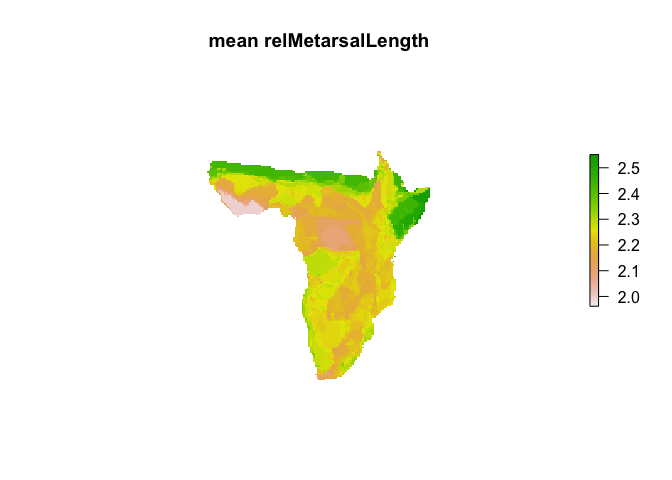

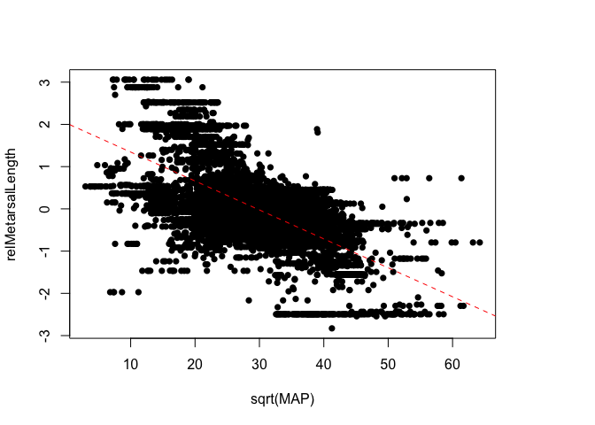

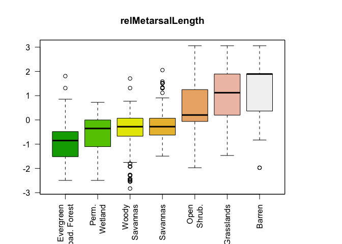

| label | intercept | SEI | slope | SES | r2 |
| --- | --- | --- | --- | --- | --- |
| MAP~relMetarsalLength | 2.03 | 0.03 | -0.07 | 0 | 0.42 |

| label | forest | wetland | woodySav | sav | openShrub | grass | barren | r2 |
| --- | --- | --- | --- | --- | --- | --- | --- | --- |
| LC~relMetarsalLength | -1.01 | 2 | 0.68 | 0.75 | 0.5 | 1.55 | 2.33 | 0.46 |

```r
resrelMetarsalLength <- doEcometricAnalysis("relMetarsalLength", MAP, landCover, savePlots = F, plotLabel="MLEN")
```

```r
resrelMetarsalLength
```

$unscaledLC

Call: lm(formula = values(ecometric) ~ landCoverFactor)

Coefficients: (Intercept) landCoverFactorPerm.2.14429 0.05025  
landCoverFactorWoodylandCoverFactorSavannas  
0.06800 0.07471  
landCoverFactorOpen. landCoverFactorGrasslands  
0.15493 0.20063  
landCoverFactorBarren  
0.23327

$unscaledMAP

Call: lm(formula = values(ecometric) ~ sqrt(values(MAP)))

Coefficients: (Intercept) sqrt(values(MAP))  
2.448300 -0.006858

## relMetatarsalDepth

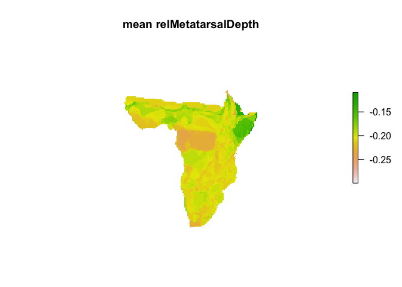

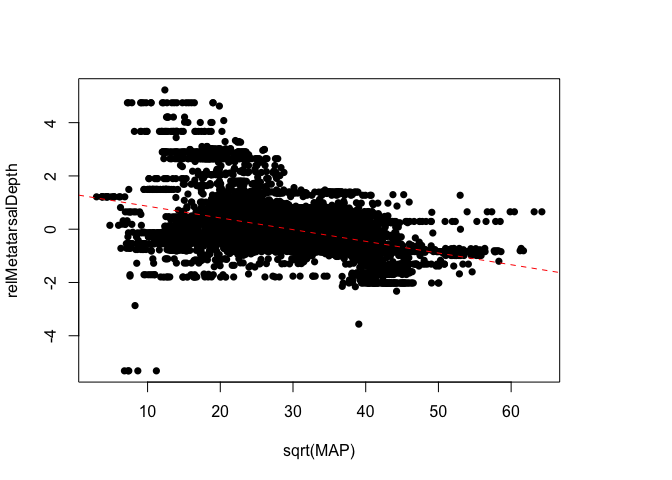

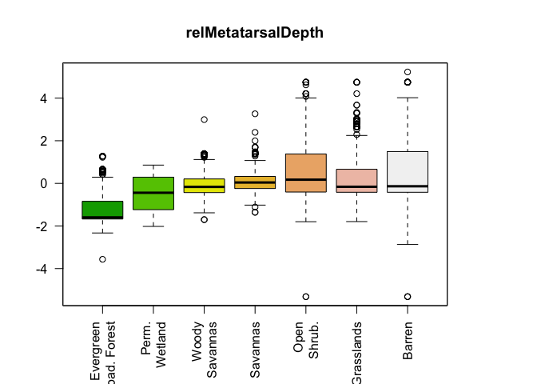

| label | intercept | SEI | slope | SES | r2 |
| --- | --- | --- | --- | --- | --- |
| MAP~relMetatarsalDepth | 1.3 | 0.03 | -0.04 | 0 | 0.17 |

| label | forest | wetland | woodySav | sav | openShrub | grass | barren | r2 |
| --- | --- | --- | --- | --- | --- | --- | --- | --- |
| LC~relMetatarsalDepth | -1.25 | 1.51 | 1.12 | 1.32 | 0.76 | 1.81 | 1.86 | 0.29 |

```r
resrelMetatarsalDepth <- doEcometricAnalysis("relMetatarsalDepth", MAP, landCover, savePlots = F, plotLabel="MDepth")
```

```r
resrelMetatarsalDepth
```

$unscaledLC

Call: lm(formula = values(ecometric) ~ landCoverFactor)

Coefficients: (Intercept) landCoverFactorPerm.-0.22626 0.01381  
landCoverFactorWoodylandCoverFactorSavannas  
0.02034 0.02382  
landCoverFactorOpen. landCoverFactorGrasslands  
0.03286 0.02731  
landCoverFactorBarren  
0.03365

$unscaledMAP

Call: lm(formula = values(ecometric) ~ sqrt(values(MAP)))

Coefficients: (Intercept) sqrt(values(MAP))  
-0.1800813 -0.0007957

## medialVert

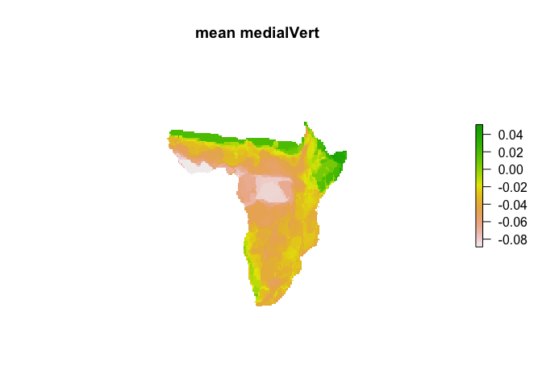

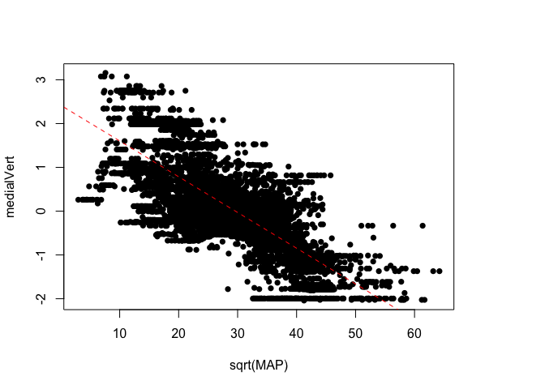

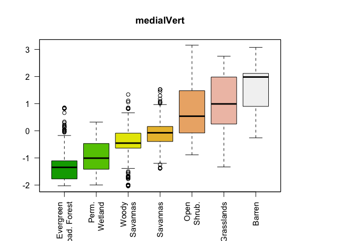

| label | intercept | SEI | slope | SES | r2 |
| --- | --- | --- | --- | --- | --- |
| MAP~medialVert | 2.42 | 0.02 | -0.08 | 0 | 0.6 |

| label | forest | wetland | woodySav | sav | openShrub | grass | barren | r2 |
| --- | --- | --- | --- | --- | --- | --- | --- | --- |
| LC~medialVert | -1.37 | 2.38 | 0.97 | 1.28 | 0.43 | 2.05 | 2.97 | 0.64 |

```r
resmedialVert <- doEcometricAnalysis("medialVert", MAP, landCover, savePlots = F, plotLabel="MVAP")
```

```r
resmedialVert
```

$unscaledLC

Call: lm(formula = values(ecometric) ~ landCoverFactor)

Coefficients: (Intercept) landCoverFactorPerm.-0.07082 0.01153  
landCoverFactorWoodylandCoverFactorSavannas  
0.02609 0.03458  
landCoverFactorOpen. landCoverFactorGrasslands  
0.05521 0.06399  
landCoverFactorBarren  
0.08005

$unscaledMAP

Call: lm(formula = values(ecometric) ~ sqrt(values(MAP)))

Coefficients: (Intercept) sqrt(values(MAP))  
0.031235 -0.002199

## distalArticular

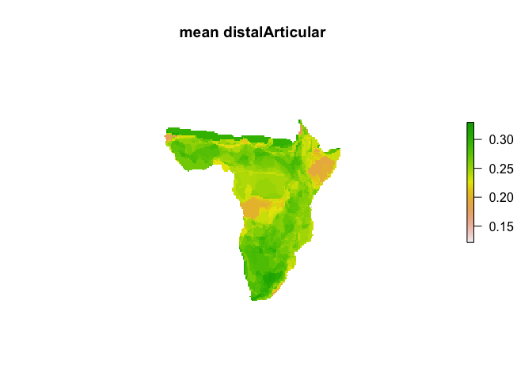

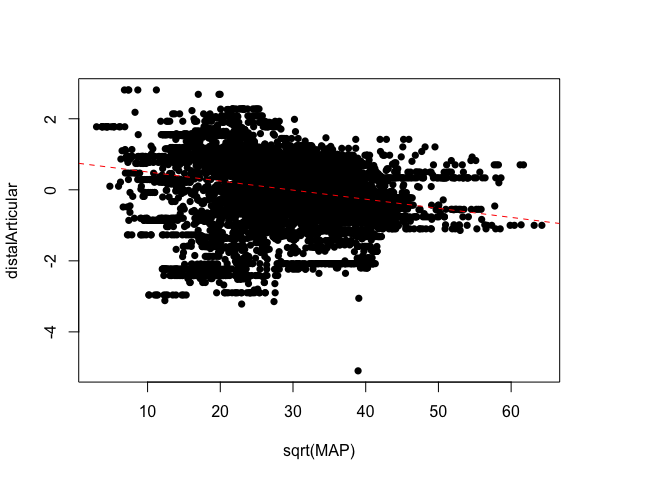

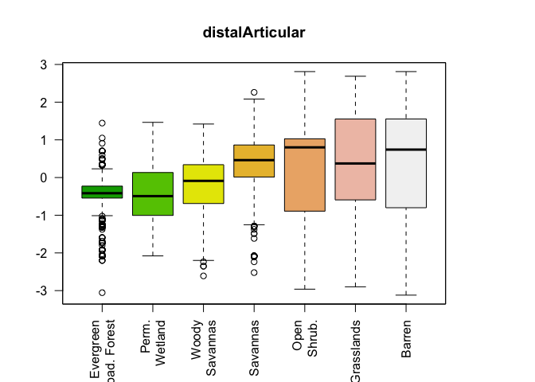

| label | intercept | SEI | slope | SES | r2 |
| --- | --- | --- | --- | --- | --- |
| MAP~distalArticular | 0.76 | 0.04 | -0.03 | 0 | 0.06 |

| label | forest | wetland | woodySav | sav | openShrub | grass | barren | r2 |
| --- | --- | --- | --- | --- | --- | --- | --- | --- |
| LC~distalArticular | -0.46 | 0.78 | 0.22 | 0.84 | 0.02 | 0.56 | 0.8 | 0.1 |

```r
resdistalArticular <- doEcometricAnalysis("distalArticular", MAP, landCover, savePlots = F, plotLabel="IDML")
```

```r
resdistalArticular
```

$unscaledLC

Call: lm(formula = values(ecometric) ~ landCoverFactor)

Coefficients: (Intercept) landCoverFactorPerm.0.2434655 0.0005821  
landCoverFactorWoodylandCoverFactorSavannas  
0.0058924 0.0221279  
landCoverFactorOpen. landCoverFactorGrasslands  
0.0147829 0.0203959  
landCoverFactorBarren  
0.0209668

$unscaledMAP

Call: lm(formula = values(ecometric) ~ sqrt(values(MAP)))

Coefficients: (Intercept) sqrt(values(MAP))  
0.2755879 -0.0006725